# Communicate Data Findings

## Investigation Overview

In this investigation, I wanted to look at the Users of the share system of GoFord Bike and see weather Age, Gender or the kind of users can be predictier varibles.

## Dataset Overview

We have 3 different data sources in the web page.

1. A CSV file for forgobike 2017
2. A number of 12 zip files for forgobike 2018 for 12 months
3. A number of 4 zip files for forgobike 2019 for 4 months in year 2019 Note: There is another 5 months has a different name in 2019 wont be included here because they maigh be from different activities if we need to we easyly add another function for that. The data have 2959104 records with two type of users "Customer and Subscribers" and about 77,000 data point were removed due the missing values or the oultliers.

## Customers Vs Subscribers

As you can see in the left side There are Only 11.5% of the users are customer whereas 88.5% are Subscriber.

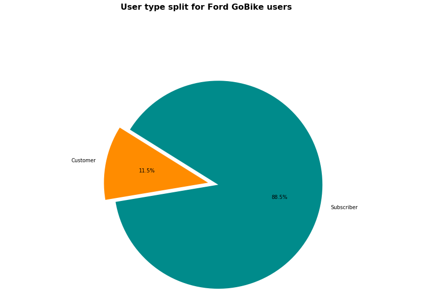

```python
plt.figure(figsize = [14.70, 8.27])
# the pie chart
plt.subplot(1, 1, 1)

labels = ['Customer', 'Subscriber']
sizes = [customer_group, subscriber_group]
colors = ['darkorange', 'darkcyan']
explode = (0, 0.1)

plt.pie(sizes, explode=explode, labels=labels, colors = colors,
        autopct='%1.1f%%', shadow=False, startangle=148)
plt.axis('equal')

plt.suptitle('User type split for Ford GoBike users', y=1.1, fontsize=16, fontweight='bold');
```

## Gender for each type of users

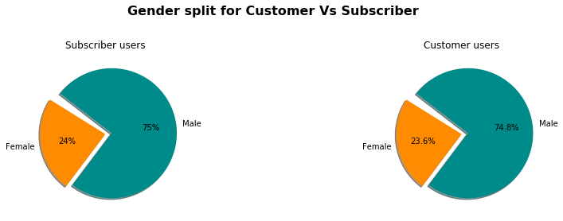

```python
labels = ['Female', 'Male']
sizes1 = [customer_female, customer_male]
sizes2 = [subscriber_female, subscriber_male]
colors = ['darkorange', 'darkcyan']

# Make square figures and axes
plt.figure(1, figsize=(14.70,8.27))
the_grid = GridSpec(2, 2)

# the pie chart "Customer"
plt.subplot(the_grid[0,1], aspect=1, title='Customer users')
Cus_users_pie = plt.pie(sizes2, explode=(0, 0.1), labels=labels, colors = colors,
        autopct='%1.1f%%', shadow=True, startangle=148)

# the pie chart "Subscriber"
plt.subplot(the_grid[0,0], aspect=1, title='Subscriber users')
sub_users_pie = plt.pie(sizes2, explode=(0, 0.1), labels=labels, colors = colors,
        autopct='%.0f%%', shadow=True, startangle=148)
plt.suptitle('Gender split for Customer Vs Subscriber', fontsize=16, fontweight='bold');

plt.show()
```

## Customer Vs Subscriber by the Group of Age for based on Gender

There is one siginfcant different btween Customers and subscribers for the group of Age based on Gender as you can see that the group of Age 20-30 are the most group for female in the customer type of users whereas the in the subscriber type the group of 30-40 of age for female have the highest number. And both type of users have the same results for the male gender and others with the most number of users by the group of age.

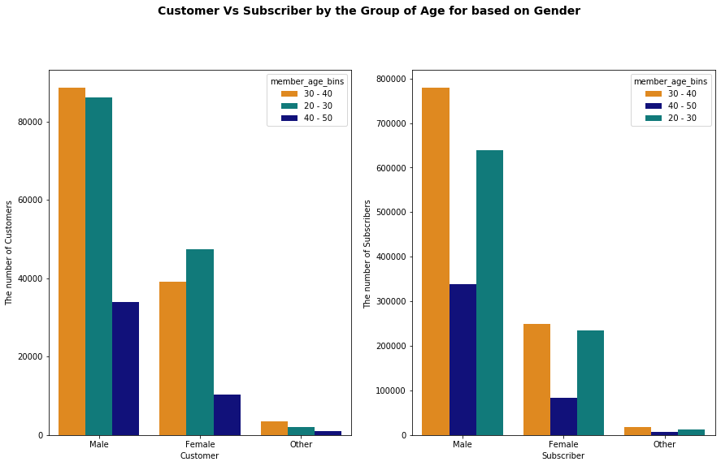

```python
# set color to use in the next few charts
palette = {'20 - 30': 'darkcyan', '30 - 40': 'darkorange', '40 - 50': 'darkblue'}

plt.figure(figsize = [14.70, 8.27])

# the bar chart
plt.subplot(1, 2, 1)
bar_chart = sns.countplot(x="member_gender", hue="member_age_bins"
                          , palette=palette, data=customer[customer['member_age_bins'].isin(['20 - 30', '30 - 40', '40 - 50'])])

bar_chart.set_xlabel('Customer')
bar_chart.set_ylabel('The number of Customers')
plt.subplot(1, 2, 2)
bar_chart = sns.countplot(x="member_gender", hue="member_age_bins"
                          , palette=palette, data=subscriber[subscriber['member_age_bins'].isin(['20 - 30', '30 - 40', '40 - 50'])])
bar_chart.set_xlabel('Subscriber')
bar_chart.set_ylabel('The number of Subscribers ')
plt.suptitle('Customer Vs Subscriber by the Group of Age for based on Gender ', fontsize=14, y=1.013, fontweight='bold');
```

## Customer Vs Subscriber by The number of the Bike Trips based on the Group of Age of each month

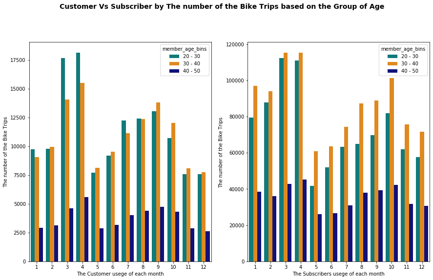

```python
plt.figure(figsize = [14.70, 8.27])

# the bar chart
plt.subplot(1, 2, 1)
bar_chart = sns.countplot(x="start_time_month", hue="member_age_bins"
                          , palette=palette, data=customer[customer['member_age_bins'].isin(['20 - 30', '30 - 40', '40 - 50'])]
                          .sort_values(by=['start_time_month','member_age_bins']))

bar_chart.set_xlabel('The Customer usege of each month')
bar_chart.set_ylabel('The number of the Bike Trips')
plt.subplot(1, 2, 2)
bar_chart = sns.countplot(x="start_time_month", hue="member_age_bins"
                          , palette=palette, data=subscriber[subscriber['member_age_bins'].isin(['20 - 30', '30 - 40', '40 - 50'])]
                          .sort_values(by=['start_time_month','member_age_bins']))
bar_chart.set_xlabel('The Subscribers usege of each month')
bar_chart.set_ylabel('The number of the Bike Trips ')
plt.suptitle('Customer Vs Subscriber by The number of the Bike Trips based on the Group of Age ', fontsize=14, y=1.013, fontweight='bold');
```

## Customer Vs Subscriber by The number of the Bike Trips based on the Group of Age on Weekdays

An overall of the Customer Vs Sub weekly usage as you can see in the charts above that the customer type of users have less usegs during the weekdays and more on the weekends whereas quite the opposite for the subscribers type of users raides more during the weekdays rather than weekends and the more interesting part here is that in both type of users the group of age 20-30 ride more on the weekends and the group of 30-40 of age rides more on weekdays.

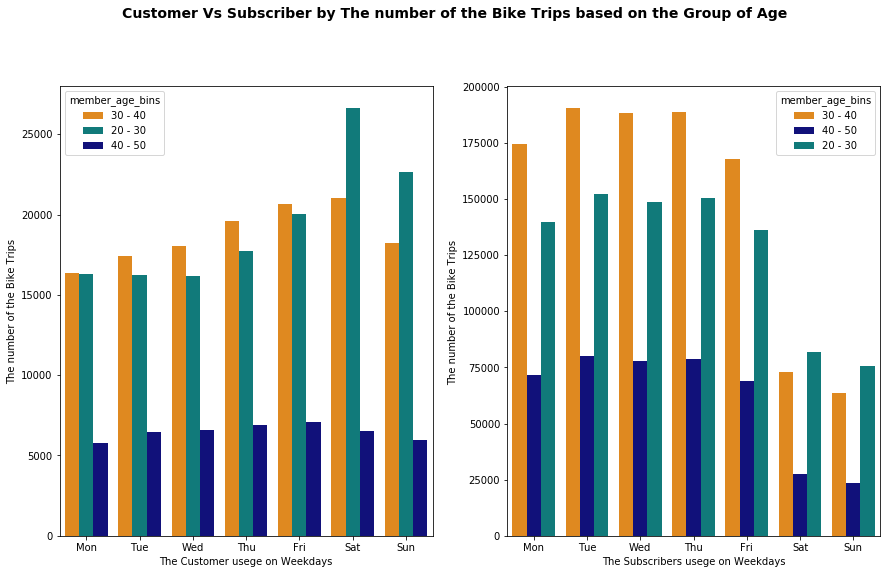

```python
plt.figure(figsize = [14.70, 8.27])
weekday = ['Mon', 'Tue', 'Wed', 'Thu', 'Fri', 'Sat', 'Sun']

# the bar chart
plt.subplot(1, 2, 1)
bar_chart = sns.countplot(x="start_time_weekday", hue='member_age_bins',palette=palette, data=customer[customer['member_age_bins']
                                                                                                                                              .isin(['20 - 30', '30 - 40', '40 - 50'])],order = weekday)

bar_chart.set_xlabel('The Customer usege on Weekdays')
bar_chart.set_ylabel('The number of the Bike Trips')
plt.subplot(1, 2, 2)
bar_chart = sns.countplot(x="start_time_weekday", hue='member_age_bins',palette=palette, data=subscriber[subscriber['member_age_bins']
                                                                                                                                              .isin(['20 - 30', '30 - 40', '40 - 50'])],order = weekday)
bar_chart.set_xlabel('The Subscribers usege on Weekdays')
bar_chart.set_ylabel('The number of the Bike Trips ')
plt.suptitle('Customer Vs Subscriber by The number of the Bike Trips based on the Group of Age ', fontsize=14, y=1.013, fontweight='bold');
```